# Lake Mendota Models

Jessi Cisewski Kehe

Fall 2020

This R Markdown document is adapted from a document created by Professor Bret Lager.

## R Markdown

- This R Markdown document contains equations which are written using $\LaTeX$. You don’t have to understand the syntax, but if you are interested you can learn more at www.latex-project.org/.
- For a nice introduction to R Markdown, including $\LaTeX$, you can see this article by Professor Cosma Shalizi [here](http://www.stat.cmu.edu/~cshalizi/rmarkdown/#putting-it-all-together-writing-your-report-in-r-markdown).

## Read Data

Make sure to put R Markdown file and data file in the same folder.

```r
mendota <- read_csv("lake-mendota-clean-2020.csv")
```

## Models for Freeze Duration by Year

- In previous lectures, we have tried out different ways to graph the freeze durations versus year
  - We added a *smooth curve* to some plots to estimate a trend
- The curve may be thought of as a fitted model where the value of the curve at a given year is an estimate of some underlying “true expected value” of the freeze duration during the year
  - The *actual* (i.e., observed) freeze duration deviates from this true value by a random amount in any given year
  - But there may also be a long-term increasing or decreasing trend as well
- If present, this trend is what we would like to try to capture with a model

### Three models

We will consider three models that we will fit and then investigate further: (i) no time effect model, (ii) linear model, and (iii) local linear regression model.

#### Model Specification

$$y_i = f(x_i) + \varepsilon_i$$

where $f$ is some function and $\varepsilon_i$ is a random value from a distribution centered at zero. It is common to assume that the $\{\varepsilon_i\}$ are independent of each other and distributed according to a normal distribution (a symmetric bell-shaped curve). We write this as
$$\varepsilon_i \sim \mathrm{Normal}(0,\sigma)$$
where $0$ is the mean and $\sigma$ is a positive value that represents the standard deviation of the normal distribution. More on this later.

Our data are measured as integers (a number of days), but we can consider the duration of time the lake is frozen in a winter to have a continuous distribution with observations rounded to an integer due to measurement limitations.

#### No time effect model

This first model assumes that there is no trend in the freeze duration with time so that $f(x_i)$ is a constant value; we’ll denote this constant as $\mu$.

$$y_i = \mu + \varepsilon_i$$

This model has two (unknown) parameters to fit ($\mu$ and $\sigma$).

- $\mu$ is interpreted as the expected duration of freezing in each year
- $\sigma$ is interpreted as the size of a typical difference between the actual freeze duration in a year and that predicted by the model

#### Linear model

The second model assumes a linear trend in the mean freeze duration with time.

$$f(x_i) = \beta_0 + \beta_1 x_i$$

This model has three parameters, ($\beta_0$, $\beta_1$, and $\sigma$).

- $\beta_0$ represents the freeze duration when the year is $x_i=0$. -Our data range from about 1855 to 2020 so a year of 0 is quite an extrapolation.
  - We could transform the $x$ variable (say, by subtracting a constant such as 1855, 1900, 1950, or 2000) from the year so that $x=0$ would correspond to a value in the range of the data to make the intercept $\beta_0$ more interpretable, but this is unnecessary.
- $\beta_1$ is the slope of the line and represents the change (a decrease if negative) of the average freeze duration each year.
  - This is the relevant parameter value for interpreting the data to address the primary scientific question about whether there is an association between time and freeze duration.
- $\sigma$ has the same interpretation as in the previous model.

#### Local Linear Regression Model

In the final model, $f(x)$ is estimated to be a smooth curve which requires more parameters than just 2 to describe. The parameters of such a model are difficult to interpret, but the graph of the curve adapts to the shape of the data. The extent to which local features affect the shape depend on a particular input parameter.

### Evaluating Models with Residual Plots

For each model, let $\hat{y}_i$ represent the value *predicted* by the model for the data point $y_i$.

Data scientists are interested in evaluating the performance of their model. One consideration is how far $\hat{y}_i$ is from $y_i$; this distance is called the residual.

The $i$th residual may be defined as
$$r_i = y_i - \hat{y}_i$$
Notice that if $y_i > \hat{y}_i$, then $r_i$ is positive; if $y_i < \hat{y}_i$ then $r_i$ is negative; if $y_i = \hat{y}_i$ then $r_i = 0$.

- We will want to graph the residual versus the explanatory variable $x$ (the first year of the winter) and look for patterns. Why might this be useful?
- We also will summarize the residuals by computing their *standard deviation* $s$. The general form of a sample standard deviation of numbers $x_1,\ldots,x_n$ which have mean $\bar{x} = \frac{1}{n}\sum_{i=1}^nx_i$ is
  $$s = \sqrt{ \frac{\sum_{i=1}^n (x_i - \bar{x})^2}{n-1} }$$
  which is (almost) the square root of the average squared deviation from the mean.
- When we estimate residuals, the mean will be (up to numerical error) equal to zero, so we are (almost) calculating the square root of the mean of the squared residuals.
- The reason we divide by $n-1$ instead of $n$ has to do with a result from mathematical statistics about the expected value of the square of the sample standard deviation, called the sample variance.

## Fitted Models, Plots, and Summaries

We have mathematically defined our three models of interest (more or less), and now we will fit the models and assess the fits.

### Removing Missing Data

This code will *select* relevant variables and then eliminate years for which the duration data is missing. In this clean data set, there are no missing values so none of the rows are removed.

```r
mendota2 = mendota %>%
  select(winter,year1,days) %>% # select the variables
  drop_na() # drop rows that having values missing

dim(mendota) # dimension of original data frame
```

```
## [1] 165   7
```

```r
dim(mendota2) # dimension of new data frame
```

```
## [1] 165   3
```

#### Fit the Models

This code will fit each of the three models and store the results as an object containing the fitted values and residuals for each model.

```r
fit1 <- lm(days ~ 1, data=mendota2)
fit2 <- lm(days ~ year1, data=mendota2)
fit3 <- loess(days ~ year1, data=mendota2)

r1 <- residuals(fit1)
r2 <- residuals(fit2)
r3 <- residuals(fit3)

mendota3 <- mendota2 %>%
  mutate(fit1 = fitted(fit1), # Add a column to our data frame with the fitted values and residuals
         residuals1 = r1,
         fit2 = fitted(fit2),
         residuals2 = r2,
         fit3 = fitted(fit3),
         residuals3 = r3)
```

### Graphs

#### Model 1: no time effect

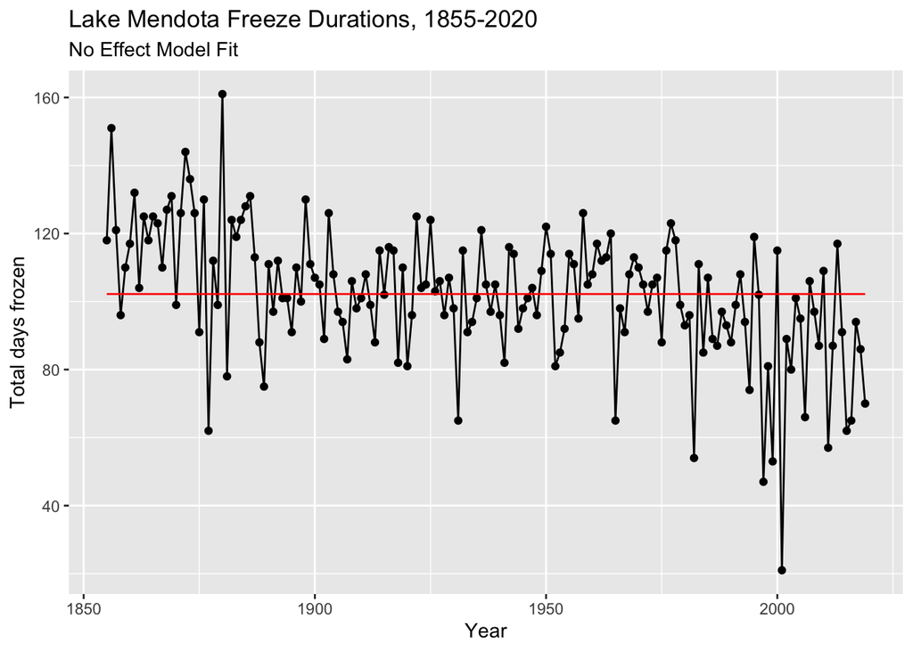

```r
ggplot(mendota3) +
  geom_line(aes(x=year1,y=days)) + # plots data as line
  geom_point(aes(x=year1,y=days)) + # plots data as points
  geom_line(aes(x=year1,y=fit1), color="red") + # plots fitted model as a line in red
  ylab("Total days frozen") + # add y-axis label
  xlab("Year") + # add x-axis label
  ggtitle("Lake Mendota Freeze Durations, 1855-2020",
          subtitle = "No Effect Model Fit") # add title and subtitle
```

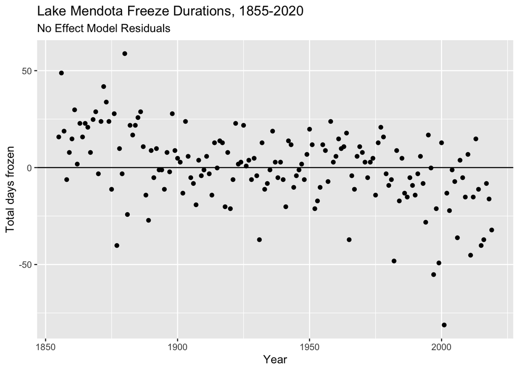

```r
ggplot(mendota3) +
  geom_point(aes(x=year1,y=residuals1)) +
  geom_hline(yintercept=0) + # plots horizontal line at `yintercept=0`
  ylab("Total days frozen") +
  xlab("Year") +
  ggtitle("Lake Mendota Freeze Durations, 1855-2020",
          subtitle = "No Effect Model Residuals")
```

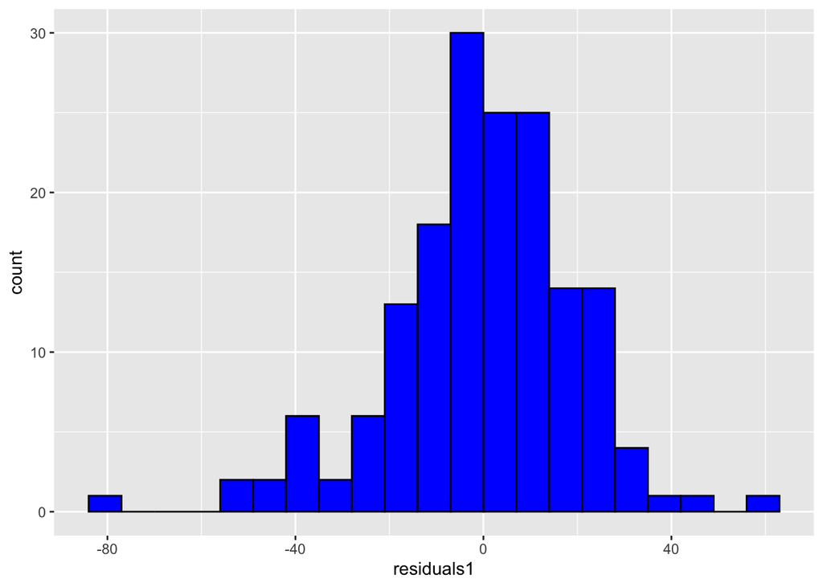

```r
ggplot(mendota3) +
  geom_histogram(aes(x=residuals1), boundary=0, binwidth=7, # plots a histogram of the residuals
                 color="black", fill = "blue")
```

The estimate of $\sigma$ is 19.6 (the standard deviation of the residuals).

#### Model 2: linear

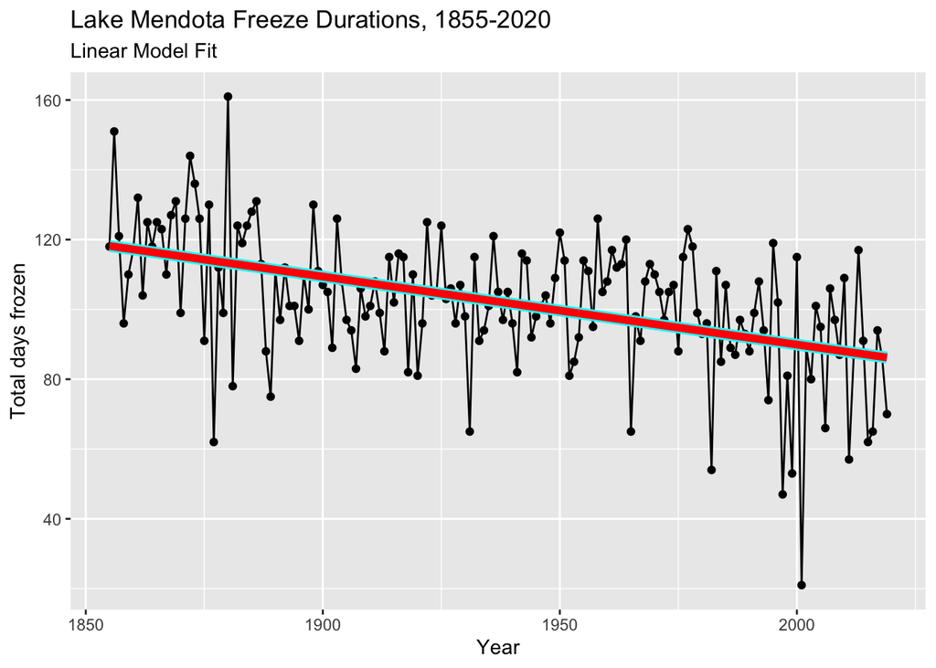

```r
ggplot(mendota3, aes(x=year1,y=days)) +
  geom_line() +
  geom_point() +
  geom_smooth(se=FALSE,method="lm",color="cyan",size=3) + # this fits the same line as model 2
  geom_line(aes(x=year1,y=fit2), color="red", size=2) + # plots fitted model as a line in red
  ylab("Total days frozen") +
  xlab("Year") +
  ggtitle("Lake Mendota Freeze Durations, 1855-2020",
          subtitle = "Linear Model Fit")
```

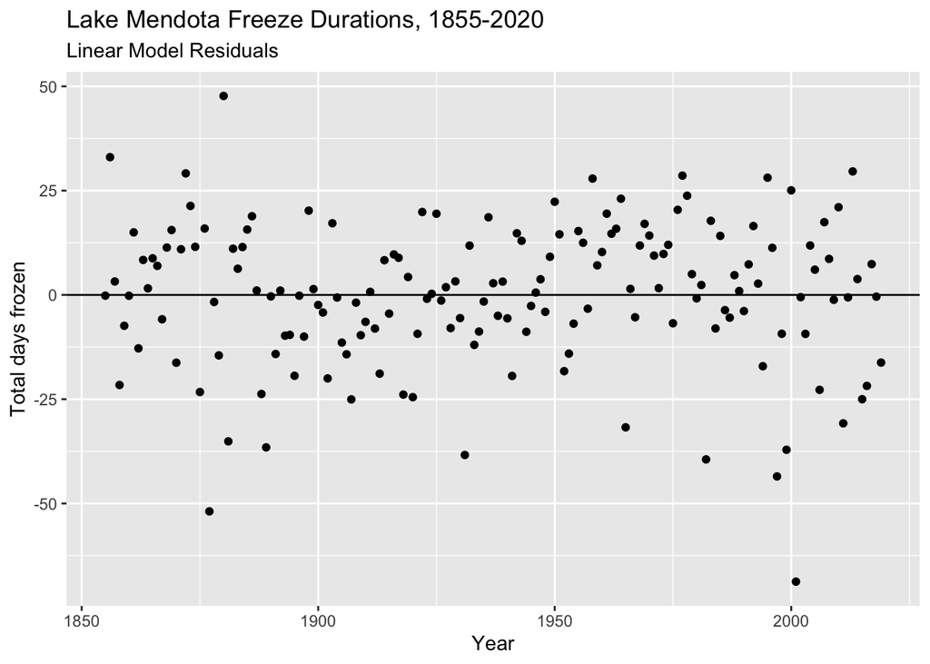

```r
ggplot(mendota3) +
  geom_point(aes(x=year1,y=residuals2)) +
  geom_hline(yintercept=0) +
  ylab("Total days frozen") +
  xlab("Year") +
  ggtitle("Lake Mendota Freeze Durations, 1855-2020",
          subtitle = "Linear Model Residuals")
```

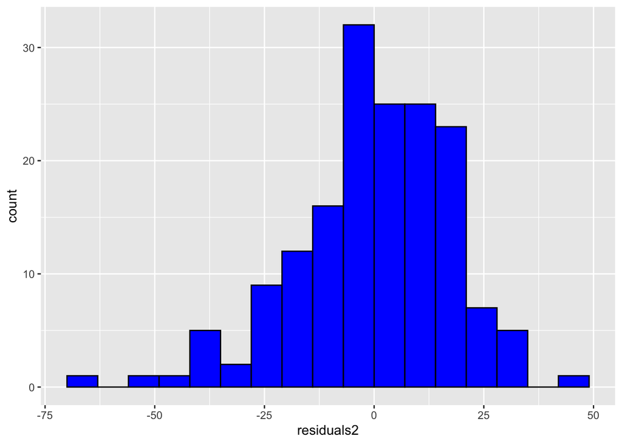

```r
ggplot(mendota3) +
  geom_histogram(aes(x=residuals2), boundary=0, binwidth=7,
                 color="black", fill = "blue")
```

The estimate of $\sigma$ is $\hat{\sigma}=$ 17.3.

The estimated slope $\hat{\beta}_1=$ -0.19.

#### Model 3: local linear

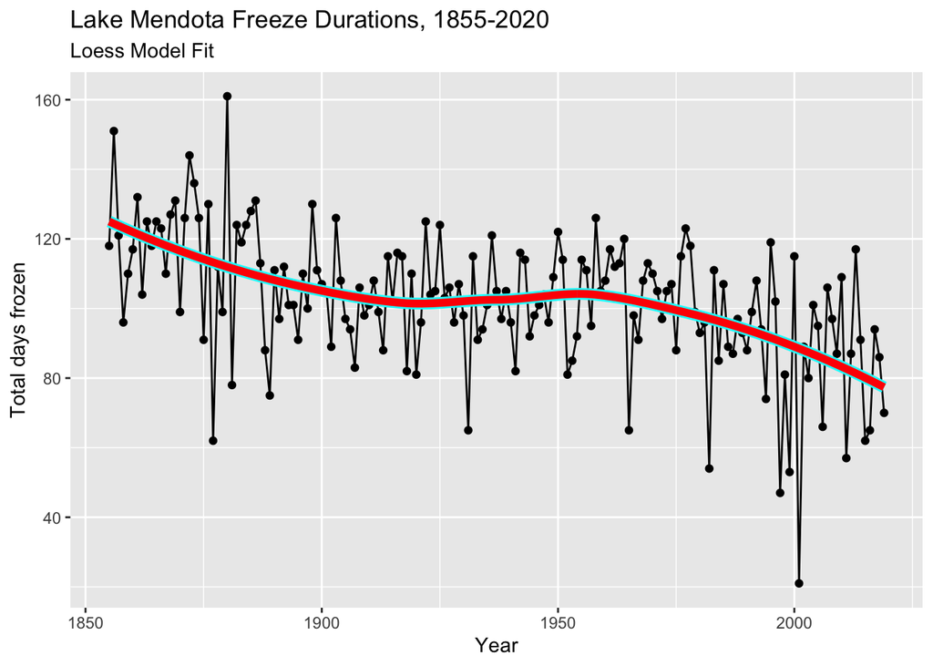

```r
ggplot(mendota3, aes(x=year1,y=days)) +
  geom_line() +
  geom_point() +
  geom_smooth(se=FALSE, color="cyan",size=3) + # this fits the same line as model 3
  geom_line(aes(x=year1,y=fit3), color="red", size=2) + # plots fitted model as a line in red
  ylab("Total days frozen") +
  xlab("Year") +
  ggtitle("Lake Mendota Freeze Durations, 1855-2020",
          subtitle = "Loess Model Fit")
```

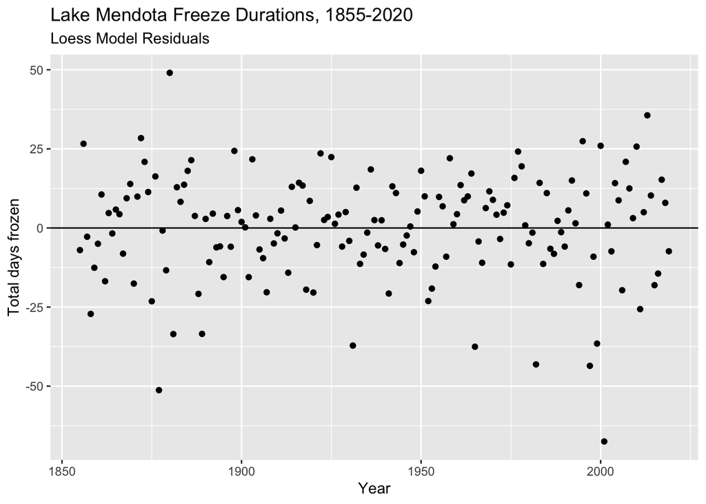

```r
ggplot(mendota3) +
  geom_point(aes(x=year1,y=residuals3)) +
  geom_hline(yintercept=0) +
  ylab("Total days frozen") +
  xlab("Year") +
  ggtitle("Lake Mendota Freeze Durations, 1855-2020",
          subtitle = "Loess Model Residuals")
```

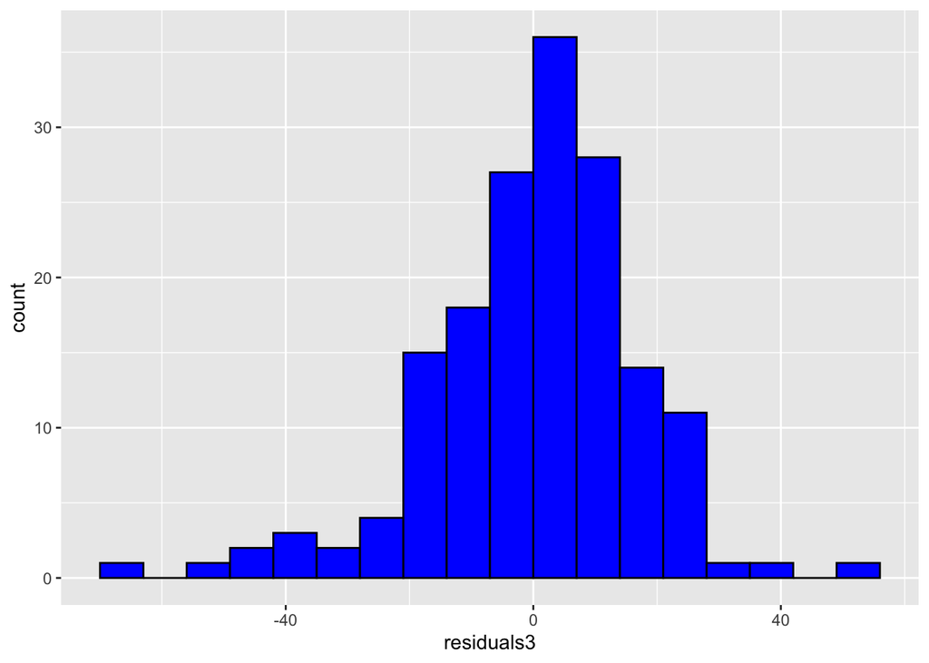

```r
ggplot(mendota3) +
  geom_histogram(aes(x=residuals3), boundary=0, binwidth=7,
                 color="black", fill = "blue")
```

The estimate of $\sigma$ is 16.8.